# CSDE 502: Homework #7

Esteban J. Valencia

2021-02-25 09:45

```r
#Step 0.0.2: Specifying chunk options
knitr::opts_chunk$set(echo = TRUE,
                      message = FALSE,
                      warning = FALSE,
                      results = "hide",
                      width = 1000)

#Step 0.0.3: Setting CRAN mirror
options(repos = "https://mirror.las.iastate.edu/CRAN/",
        width = 1000)

#Step 0.0.4: Installing & Reading packages
if(!require (knitr)) install.packages("knitr")
library(knitr)
if(!require (bookdown)) install.packages("bookdown")
library(bookdown)
if(!require (tidyverse)) install.packages("tidyverse")
library(tidyverse)
if(!require (magisttr)) install.packages("magrittr")
(library(magrittr))
if(!require (kableExtra)) install.packages("kableExtra")
library(kableExtra)
if(!require (ggplot2)) install.packages("ggplot2")
library(ggplot2)
if(!require (readstata13)) install.packages("readstata13")
library(readstata13)
if(!require (captioner)) install.packages("captioner")
library(captioner)
if(!require (Rmisc)) install.packages("Rmisc")

#Step 0.0.5: Setting captions
cap.tab = captioner(prefix = "Table")
cap.fig = captioner(prefix = "Figure")

#Step 0.0.6: Setting temporary file directory and temporary file
f.dir = paste0(tempdir(), "/")
f.temp = tempfile()

#Step 0.0.7: Downloading/opening Add Health zip-file.

  ##Naming html address
  f.url = "http://staff.washington.edu/phurvitz/csde502_winter_2021/data/21600-0001-Data.dta.zip"

  ##Setting path for zipfile
  z.file = file.path(Sys.getenv("TEMP"), basename(f.url))

  ##Setting file in temporary folder
  f.data = tools::file_path_sans_ext(z.file)

  ##Check-loop: Does file exist?
  if(!file.exists(f.data)){

    ###If the file does not exist...
    if(!file.exists(z.file)){
      curl::curl_download(url = f.url, destfile = z.file)
    }

    ###If the file does exist...
    unzip(ziipfile = z.file, exdir = Sys.getenv("TEMP"))
  }

  ##Check-loop: Has file been read? If not, reading in file...
  if(!exists("adh.data")) {
    adh.data = haven::read_dta(f.data)
  }

  ##Changing column names to lower case
  colnames(adh.data) %<>% str_to_lower()
```

# 1 Introduction

The following file describes the subsetting and tabulation of data from Add Health. The full Add Health wave 1 data have been downloaded, and consist of 2794 variables. We will parse this down to just 5 variables.

```r
#Step 1.0.1: Subsetting data
s.adh = subset(adh.data,
               select = c(h1ed7, h1ed11, h1ed12, h1ed13, h1ed14))

#Step 1.0.2: Renaming data
s.adh %<>% dplyr::rename(suspensions = h1ed7,
                         gr_english = h1ed11,
                         gr_maths = h1ed12,
                         gr_history = h1ed13,
                         gr_science = h1ed14)

#Step 1.0.3: Rendering variables as factors
s.adh %<>% lapply(FUN = function(x) factor(x,
                                           ordered = is.ordered(x),
                                           labels = attributes(unlist(attributes(x)$labels))$names))
s.adh = data.frame(s.adh)
```

Once the data frame is subset, we can examine the variables we have selected by variable name and variable label.

```r
#Step 1.0.4: Specifying metadata
m.data = bind_cols(varname = colnames(s.adh),
                   varlabel = s.adh %>% map(~attributes(.)$label) %>% unlist())

#Step 1.0.5: Printing variable table
DT::datatable(m.data)
```

[output not shown]

# 2 Tables

Below presents a frequency tabulation of the variable `$suspensions`.

```r
#Step 2.0.1: Tabulation
tab.x = table(s.adh$suspensions)
tab.y = round(prop.table(tab.x) * 100, digits = 1)
tab.z = cbind(N = tab.x, Percent = tab.y)
kable(tab.z) %>%
  kable_styling(full_width = FALSE,  position = "left")
```

N

Percent

0. No (skip to Q.9)

4687

72.1

1. Yes

1801

27.7

6. Refused (skip to Q.9)

5

0.1

8. Don’t know (skip to Q.9)

8

0.1

Below is a frequency tabulation of the variable `$gr_english`.

```r
#Step 2.0.2: Tabulation
tab.x = table(s.adh$gr_english)
tab.y = round(prop.table(tab.x) * 100, digits = 1)
tab.z = cbind(N = tab.x, Percent = tab.y)
kable(tab.z) %>%
  kable_styling(full_width = FALSE,  position = "left")
```

N

Percent

1. A

1712

26.3

2. B

2389

36.7

3. C

1435

22.1

4. D or lower

647

9.9

5. Didn’t take this subject

87

1.3

6. Took subject/wasn’t graded this way

58

0.9

96. Refused

5

0.1

97. Legitimate skip

128

2.0

98. Don’t know

43

0.7

Below is a frequency tabulation of the variable `$gr_maths`.

```r
#Step 2.0.3: Tabulation
tab.x = table(s.adh$gr_maths)
tab.y = round(prop.table(tab.x) * 100, digits = 1)
tab.z = cbind(N = tab.x, Percent = tab.y)
kable(tab.z) %>%
  kable_styling(full_width = FALSE,  position = "left")
```

N

Percent

1. A

1552

23.9

2. B

1899

29.2

3. C

1521

23.4

4. D or lower

950

14.6

5. Didn’t take this subject

353

5.4

6. Took subject/wasn’t graded this way

69

1.1

96. Refused

4

0.1

97. Legitimate skip

128

2.0

98. Don’t know

28

0.4

Below is a frequency tabulation of the variable `$gr_history`.

```r
#Step 2.0.4: Tabulation
tab.x = table(s.adh$gr_history)
tab.y = round(prop.table(tab.x) * 100, digits = 1)
tab.z = cbind(N = tab.x, Percent = tab.y)
kable(tab.z) %>%
  kable_styling(full_width = FALSE,  position = "left")
```

N

Percent

1. A

1931

29.7

2. B

1853

28.5

3. C

1182

18.2

4. D or lower

664

10.2

5. Didn’t take this subject

652

10.0

6. Took subject/wasn’t graded this way

50

0.8

96. Refused

5

0.1

97. Legitimate skip

128

2.0

98. Don’t know

39

0.6

Below is a frequency tabulation of the variable `$gr_science`.

```r
#Step 2.0.5: Tabulation
tab.x = table(s.adh$gr_science)
tab.y = round(prop.table(tab.x) * 100, digits = 1)
tab.z = cbind(N = tab.x, Percent = tab.y)
kable(tab.z) %>%
  kable_styling(full_width = FALSE,  position = "left")
```

N

Percent

1. A

1759

27.0

2. B

1860

28.6

3. C

1282

19.7

4. D or lower

685

10.5

5. Didn’t take this subject

706

10.9

6. Took subject/wasn’t graded this way

50

0.8

96. Refused

5

0.1

97. Legitimate skip

128

2.0

98. Don’t know

29

0.4

Below is a frequency cross-tabulation of the variables `$suspensions` & `$gr_english`.

```r
#Step 2.0.6: Tabulation

  ##Tabulation for No Suspensions
  tab.x1 = table(s.adh$gr_english[s.adh$suspensions == "(0) No (skip to Q.9)"])
  tab.y1 = round(prop.table(tab.x1) * 100, digits = 1)
  tab.z1 = cbind(N = tab.x1, Percent = tab.y1)
  rownames(tab.z1) = paste0(rownames(tab.z1), ":  Never Suspended")

  ##Tabulation for Yes Suspensions
  tab.x2 = table(s.adh$gr_english[s.adh$suspensions == "(1) Yes"])
  tab.y2 = round(prop.table(tab.x2) * 100, digits = 1)
  tab.z2 = cbind(N = tab.x2, Percent = tab.y2)
  rownames(tab.z2) = paste0(rownames(tab.z2), ":  Previously Suspended")

  ##Adding tabulations together
  tab.fin = rbind(tab.z1, tab.z2)

  ##Printing table
  kable(tab.fin) %>%
  kable_styling(full_width = FALSE,  position = "left")
```

N

Percent

1. A: Never Suspended

1484

31.7

2. B: Never Suspended

1821

38.9

3. C: Never Suspended

895

19.1

4. D or lower: Never Suspended

305

6.5

5. Didn’t take this subject: Never Suspended

51

1.1

6. Took subject/wasn’t graded this way: Never Suspended

38

0.8

96. Refused: Never Suspended

1

0.0

97. Legitimate skip: Never Suspended

67

1.4

98. Don’t know: Never Suspended

25

0.5

1. A: Previously Suspended

228

12.7

2. B: Previously Suspended

565

31.4

3. C: Previously Suspended

540

30.0

4. D or lower: Previously Suspended

342

19.0

5. Didn’t take this subject: Previously Suspended

36

2.0

6. Took subject/wasn’t graded this way: Previously Suspended

20

1.1

96. Refused: Previously Suspended

1

0.1

97. Legitimate skip: Previously Suspended

55

3.1

98. Don’t know: Previously Suspended

14

0.8

# 3 Plot

The below barplot graphs the distribution of `$suspesions`

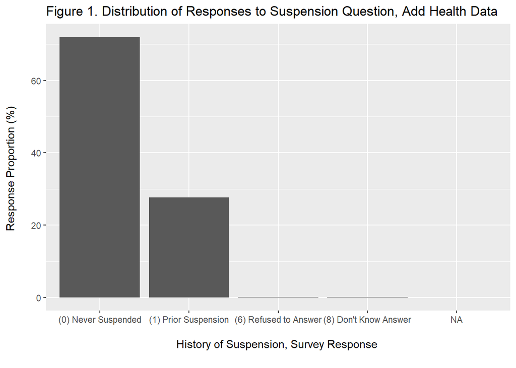

```r
#Step 3.0.1: Recoding suspension variable
attributes(s.adh$suspensions)$levels = c("(0) Never Suspended",
                                         "(1) Prior Suspension",
                                         "(6) Refused to Answer",
                                         "(8) Don't Know Answer")

#Step 3.0.2: Plotting distribution
ggplot(data = s.adh, mapping = aes(x = suspensions)) +
  geom_bar(aes(y = (..prop..) * 100, group = 1)) +
  ylab("Response Proportion (%) \n") +
  xlab("\nHistory of Suspension, Survey Response \n") +
  labs(title = "Figure 1. Distribution of Responses to Suspension Question, Add Health Data")
```

# 4 Saving data

The data are saved as an `RDS` object in a temporary directory.

```r
#Step 4.0.1: Saving data
saveRDS(s.adh, paste0(f.dir, "adh_data.rds"))
```

# 5 Source code

The source code for this document is indicated below

```r
cat(readLines(con = "estebanv_csde_502_hw7.Rmd"), sep = '\n')
```

````
## ---
## title: "CSDE 502: Homework #7"
## author: "[Esteban J. Valencia](mailto:estebanv@uw.edu)"
## date: '`r format(Sys.time(), "%Y-%m-%d %H:%M")`'
## header-includes:
## - \usepackage{float}
## - \floatplacement{figure}{H}
## output:
##     bookdown::html_document2:
##         theme: journal
##         number_sections: true
##         self_contained: true
##         code_folding: hide
##         toc: true
##         toc_float:
##             collapsed: true
##             smooth_scroll: false
## urlcolor: blue
## ---
## ```{css, echo=FALSE}
## #Step 0.0.1: Setting wide-wise scrolling
## pre, code {white-space: pre !important; overflow-x: auto}
##
## ```
## ```{r setup, warning = FALSE, message = FALSE, results = "hide"}
## #Step 0.0.2: Specifying chunk options
## knitr::opts_chunk$set(echo = TRUE,
##                       message = FALSE,
##                       warning = FALSE,
##                       results = "hide",
##                       width = 1000)
##
## #Step 0.0.3: Setting CRAN mirror
## options(repos = "https://mirror.las.iastate.edu/CRAN/",
##         width = 1000)
##
## #Step 0.0.4: Installing & Reading packages
## if(!require (knitr)) install.packages("knitr")
## library(knitr)
## if(!require (bookdown)) install.packages("bookdown")
````

[output cut: 191 more lines]

````
##
## The data are saved as an `RDS` object in a temporary directory.
##
## ```{r}
## #Step 4.0.1: Saving data
## saveRDS(s.adh, paste0(f.dir, "adh_data.rds"))
## ```
##
## # Source code
##
## The source code for this document is indicated below
##
## ```{r, results = "markdown"}
## cat(readLines(con = "estebanv_csde_502_hw7.Rmd"), sep = '\n')
## ```
````